# lab04

kts

2025-11-29

```r
set.seed(666) #чтобы рандом был одним и тем же
setwd("C:/Users/timur/OneDrive/Рабочий стол/Studying/aw5/Statistics_5/lab04")
data <- read_xlsx("Вариант124_Б23-902_Кривенко.xlsx")
nrow(data)
```

```
## [1] 36000
```

0. Подготовка данных

Поделим данные на те, где указан уровень счастья и где нет

```r
na_rows <- is.na(data$Ощущаемое_счастье)
df_pred <- data[na_rows, ]        # для прогноза
df_train <- data[!na_rows, ]       # для обучения
```

```r
summary(df_pred)
```

```
##   Респондент        Среднегодовой доход, тыс. $
##  Length:6000        Min.   :   6.694
##  Class :character   1st Qu.: 112.522
##  Mode  :character   Median : 235.210
##                     Mean   : 319.526
##                     3rd Qu.: 493.627
##                     Max.   :1228.422
##
##  Объем потребленного алкоголя в год, л. Количество членов семьи
##  Min.   :13.00                          Min.   : 1.000
##  1st Qu.:27.00                          1st Qu.: 2.000
##  Median :33.00                          Median : 4.000
##  Mean   :45.07                          Mean   : 4.225
##  3rd Qu.:70.00                          3rd Qu.: 6.000
##  Max.   :82.00                          Max.   :12.000
##
##  Количество лет образования
##  Min.   : 0.0
##  1st Qu.: 7.0
##  Median :13.0
##  Mean   :13.6
##  3rd Qu.:21.0
##  Max.   :28.0
##
##  Доля от дохода семьи которая тратится на продовольствие, %
##  Min.   :20.00
##  1st Qu.:37.00
##  Median :53.00
##  Mean   :52.11
##  3rd Qu.:65.00
##  Max.   :77.00
##
##  Коэффициент Джини сообщества Издержки сообщества на окружающую среду, млн. $
##  Min.   :-0.05423             Min.   :  0.00
##  1st Qu.: 0.31672             1st Qu.: 73.37
##  Median : 0.62295             Median :165.00
##  Mean   : 0.55796             Mean   :183.36
##  3rd Qu.: 0.81557             3rd Qu.:306.31
##  Max.   : 1.02913             Max.   :400.00
##
```

[output cut: 57 more lines]

```
##  Min.   : NA                           Min.   : NA
##  1st Qu.: NA                           1st Qu.: NA
##  Median : NA                           Median : NA
##  Mean   :NaN                           Mean   :NaN
##  3rd Qu.: NA                           3rd Qu.: NA
##  Max.   : NA                           Max.   : NA
##  NA's   :6000                          NA's   :6000
##  Чувство неравенства доходов в обществе Ощущаемое_счастье
##  Min.   : NA                            Min.   : NA
##  1st Qu.: NA                            1st Qu.: NA
##  Median : NA                            Median : NA
##  Mean   :NaN                            Mean   :NaN
##  3rd Qu.: NA                            3rd Qu.: NA
##  Max.   : NA                            Max.   : NA
##  NA's   :6000                           NA's   :6000
```

Очистим от пустых значений

```r
#в тренировочном сете удалим все Na
df_train <- na.omit(df_train)
nrow(df_train)
```

```
## [1] 30000
```

1. Определим какие признаки состояния наиболее сильно связаны с “уровнем счастья”. Для этого воспользуемся **коэффициентом корреляции Спирмана**. Его используем потому, что в отличие от Пирсона, тут используются ранги.

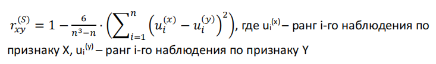

Для оценки силы корреляции будем пользоваться **шкалой Чеддока**

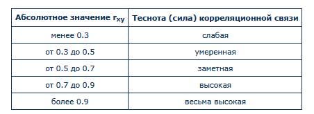

```r
spearman_matrix = data.frame(matrix(nrow=11, ncol=4))
names(spearman_matrix) <- c('№', 'Признак', 'Значение', 'Вывод')
a <- df_train[, 25]
for (i in 13:24){
  b <- df_train[, i]
  c <- cor(x = a,
    y = b,
    method = "spearman",
    "complete.obs")
  spearman_matrix[i-13, 1] <- i
  spearman_matrix[i-13, 2] <- colnames(df_train[i])
  spearman_matrix[i-13, 3] <- c[1]
  if (abs(c[1]) < 0.3){
     spearman_matrix[i-13, 4] <- "Слабая корреляция"
  } else if (abs(c[1]) >= 0.3 & abs(c[1]) < 0.5){
    spearman_matrix[i-13, 4] <- "Умеренная корреляция"
  } else if (abs(c[1]) >= 0.5 & abs(c[1]) < 0.7){
    spearman_matrix[i-13, 4] <- "Заметная корреляция"
  } else if (abs(c[1]) >= 0.7 & abs(c[1]) < 0.9){
    spearman_matrix[i-13, 4] <- "Высокая корреляция"
  } else {
    spearman_matrix[i-13, 4] <- "Весьма высокая корреляция"
  }

}
kable(spearman_matrix)
```

| № | Признак | Значение | Вывод |
| --- | --- | --- | --- |
| 14 | Ожидаемая продолжительность здоровой жизни | -0.9196923 | Весьма высокая корреляция |
| 15 | Свобода граждан самостоятельно принимать жизненно важные решения | -0.4749022 | Умеренная корреляция |
| 16 | Индекс Щедрости | -0.4130986 | Умеренная корреляция |
| 17 | Индекс отношения к коррупции | 0.9661461 | Весьма высокая корреляция |
| 18 | Оценка риска безработицы | -0.0012334 | Слабая корреляция |
| 19 | Индекс кредитного оптимизма | 0.0030621 | Слабая корреляция |
| 20 | Индекс страха социальных конфликтов | 0.0039722 | Слабая корреляция |
| 21 | Индекс семьи | 0.0049400 | Слабая корреляция |
| 22 | Индекс продовольственной безопасности | -0.0076598 | Слабая корреляция |
| 23 | Чувство технологического прогресса | -0.9619693 | Весьма высокая корреляция |
| 24 | Чувство неравенства доходов в обществе | -0.0002832 | Слабая корреляция |

Возьмем топ 3 признака по значимости

```r
mv_status_ind <- (head(spearman_matrix[order(abs(spearman_matrix$Значение), decreasing = TRUE), ], 3)) #Most ?Valueble? status
kable(mv_status_ind)
```

|  | № | Признак | Значение | Вывод |
| --- | --- | --- | --- | --- |
| 4 | 17 | Индекс отношения к коррупции | 0.9661461 | Весьма высокая корреляция |
| 10 | 23 | Чувство технологического прогресса | -0.9619693 | Весьма высокая корреляция |
| 1 | 14 | Ожидаемая продолжительность здоровой жизни | -0.9196923 | Весьма высокая корреляция |

Построим графики линейной зависимости.

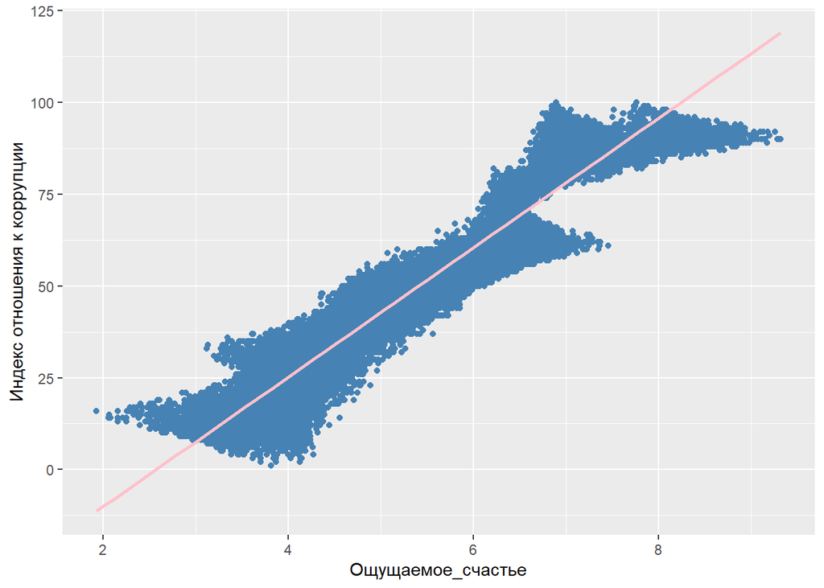

```r
#Свобода граждан самостоятельно принимать жизненно важные решения
ggplot(df_train, aes(x = Ощущаемое_счастье, y = `Индекс отношения к коррупции`)) +
  geom_point(color="steelblue") +
  geom_smooth(method = "lm", se = FALSE, color="pink")
```

```r
  labs(title = "CGPA and Package regression", x = "CGPA", y = "Y")
```

```
## <ggplot2::labels> List of 3
##  $ x    : chr "CGPA"
##  $ y    : chr "Y"
##  $ title: chr "CGPA and Package regression"
```

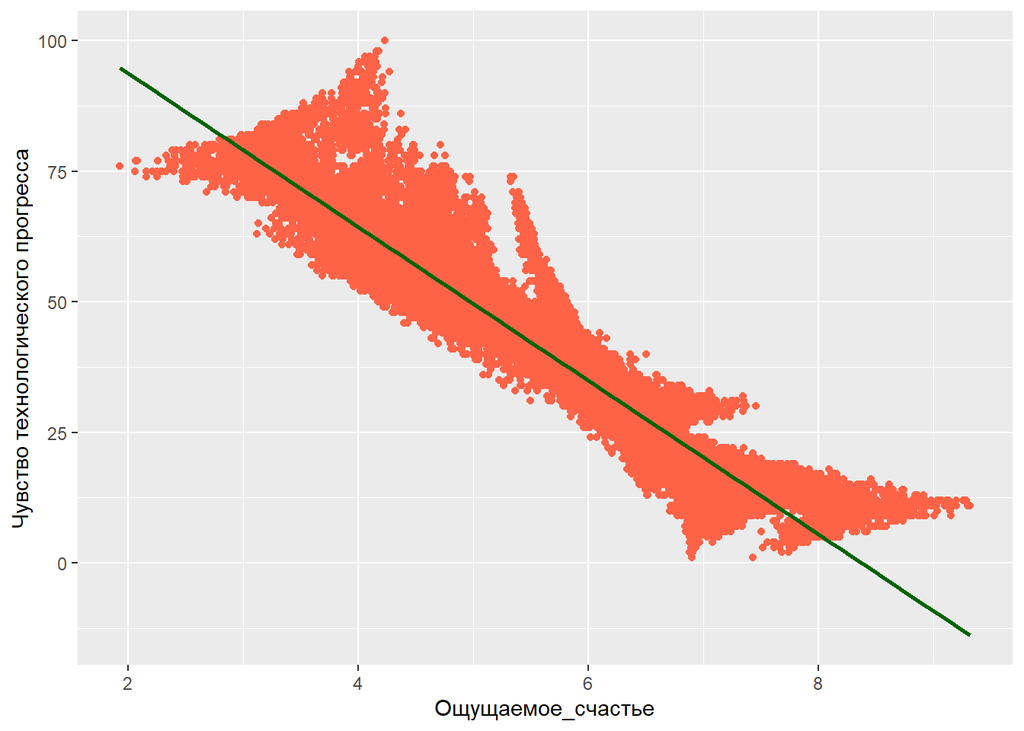

```r
ggplot(df_train, aes(x = Ощущаемое_счастье, y = `Чувство технологического прогресса`)) +
  geom_point(color="tomato") +
  geom_smooth(method = "lm", se = FALSE, color="darkgreen")
```

```r
  labs(title = "Корреляция")
```

```
## <ggplot2::labels> List of 1
##  $ title: chr "Корреляция"
```

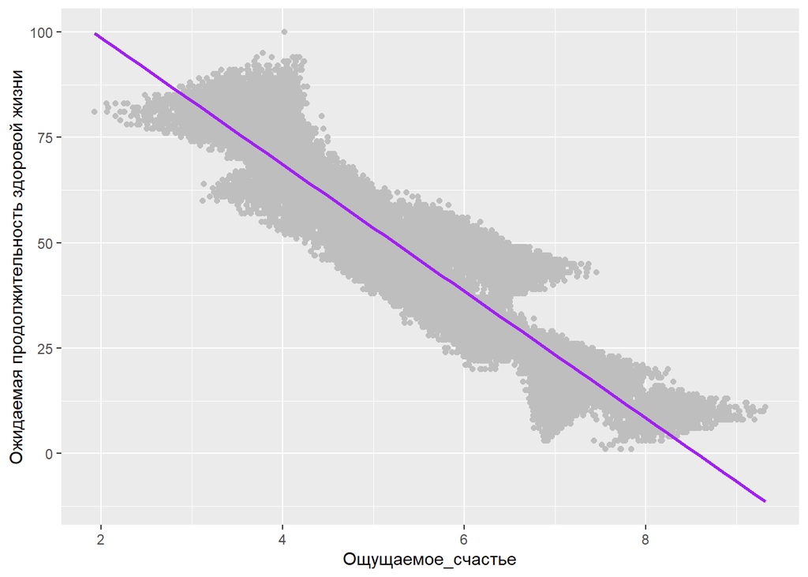

```r
ggplot(df_train, aes(x = Ощущаемое_счастье, y = `Ожидаемая продолжительность здоровой жизни`)) +
  geom_point(color="gray") +
  geom_smooth(method = "lm", se = FALSE, color="purple")
```

```r
  labs(title = "Корреляция")
```

```
## <ggplot2::labels> List of 1
##  $ title: chr "Корреляция"
```

2. Определим, как влияют признаки причины на **выбранные** признаки состояни

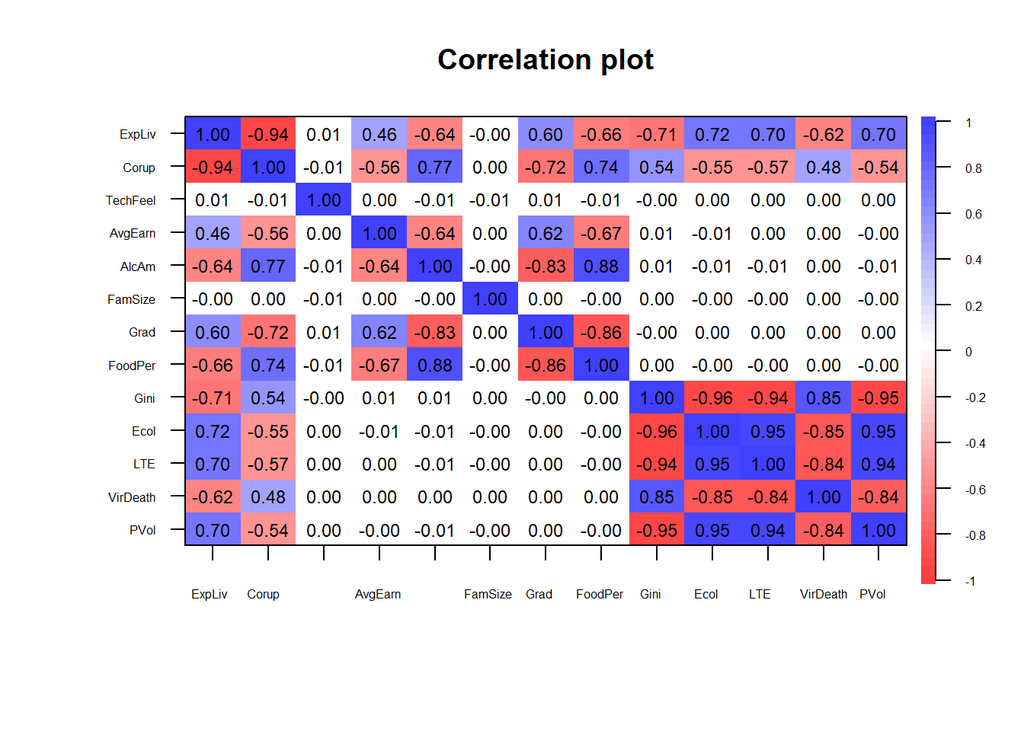

[output not shown]

```r
cols <- c(14, 17, 22, 2:13)
data_pp <- df_train[, cols]
colnames(data_pp) <- c("ExpLiv","Corup","TechFeel",
                          "AvgEarn","AlcAm","FamSize","Grad","FoodPer", "Gini","Ecol","LTE","VirDeath","PVol")
data_pp <- data_pp[, 1:13] #почему эти Na создаются????
cor.plot(cor(data_pp, method = "spearman"), cex = 0.5, cex.axis = 0.49, stars = F,
         pval = corr.test((data_pp), method = "spearman")$p)
```

Возьмем “Свобода граждан самостоятельно принимать жизненно важные решения” и “Индекс Щедрости”, хоть они и имеют умеренную корелляцию с целевой переменной счастья, возможно они будут иметь лучшую взаимосвязь с ПП, чем TechFeel

Снова построим график корелляции, но для новых ПС.

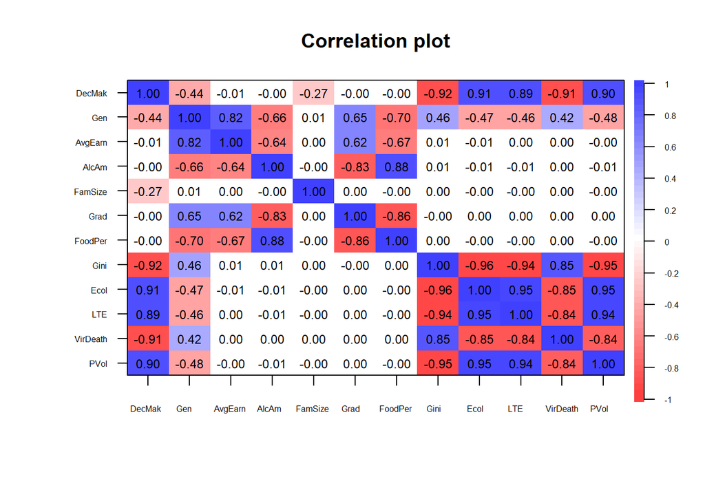

```r
cols_ <- c(15, 16, 2:13)  # 14 колонок
data_pp_ <- df_train[, cols_]
colnames(data_pp_) <- c("DecMak","Gen","AvgEarn","AlcAm","FamSize","Grad",
                        "FoodPer","Gini","Ecol","LTE","VirDeath","PVol")  # 12 имён
data_pp_ <- data_pp_[, 1:12]  # обрезаем лишние 2 колонки!

# Теперь точно работает твой старый стиль:
cor.plot(cor(data_pp_, method = "spearman"), cex = 0.5, cex.axis = 0.49, stars = FALSE,
         pval = corr.test(data_pp_, method = "spearman")$p)
```

Для DecMak возьме VirDeath, Gini, Ecol

Но для начала разделим тренировочные данные на валидационные и тренировочные.

```r
#возьмем 7000 строк из df_train и сделаем из этого валидационную выборку
valid_ind     <- sample.int(n = nrow(df_train), size = 7000)      # 7000 случайных индексов
train_ind <- setdiff(1:nrow(df_train), valid_ind)              # все остальные

df_valid     <- df_train[valid_ind, ]       # тест
df_train <- df_train[train_ind, ]
```

Построи модели для ПС, которые мы будем использовать для предсказания счастья

```r
DecMakFormula <- formula(`Свобода граждан самостоятельно принимать жизненно важные решения` ~ `Коэффициент Джини сообщества` + `Количество смертей от вирусных и респираторных заболеваний в сообществе, тыс. человек` + `Издержки сообщества на окружающую среду, млн. $`)

DecMakFormula <- formula(`Свобода граждан самостоятельно принимать жизненно важные решения` ~
                          `Коэффициент Джини сообщества` +
                          `Количество смертей от вирусных и респираторных заболеваний в сообществе, тыс. человек` +
                          `Издержки сообщества на окружающую среду, млн. $`)

CorupFormula <- formula(`Индекс отношения к коррупции` ~
                         `Объем потребленного алкоголя в год, л.` +
                         `Доля от дохода семьи которая тратится на продовольствие, %` +
                         `Количество лет образования`)

DecMakModel <- lm(DecMakFormula, data = df_train)
CorupModel <- lm(CorupFormula, data = df_train)

summary(DecMakModel)
```

```
##
## Call:
## lm(formula = DecMakFormula, data = df_train)
##
## Residuals:
##      Min       1Q   Median       3Q      Max
## -10.6488  -2.3856   0.4312   2.8404   4.7283
##
## Coefficients:
##                                                                                           Estimate
## (Intercept)                                                                              9.808e+01
## `Коэффициент Джини сообщества`                                                          -1.511e+01
## `Количество смертей от вирусных и респираторных заболеваний в сообществе, тыс. человек` -2.133e+00
## `Издержки сообщества на окружающую среду, млн. $`                                        2.210e-04
##                                                                                         Std. Error
## (Intercept)                                                                              3.148e-01
## `Коэффициент Джини сообщества`                                                           3.098e-01
## `Количество смертей от вирусных и респираторных заболеваний в сообществе, тыс. человек`  3.738e-03
## `Издержки сообщества на окружающую среду, млн. $`                                        7.792e-04
##                                                                                          t value
## (Intercept)                                                                              311.523
## `Коэффициент Джини сообщества`                                                           -48.774
## `Количество смертей от вирусных и респираторных заболеваний в сообществе, тыс. человек` -570.521
## `Издержки сообщества на окружающую среду, млн. $`                                          0.284
##                                                                                         Pr(>|t|)
## (Intercept)                                                                               <2e-16
## `Коэффициент Джини сообщества`                                                            <2e-16
## `Количество смертей от вирусных и респираторных заболеваний в сообществе, тыс. человек`   <2e-16
## `Издержки сообщества на окружающую среду, млн. $`                                          0.777
##
## (Intercept)                                                                             ***
## `Коэффициент Джини сообщества`                                                          ***
## `Количество смертей от вирусных и респираторных заболеваний в сообществе, тыс. человек` ***
## `Издержки сообщества на окружающую среду, млн. $`
## ---
## Signif. codes:  0 '***' 0.001 '**' 0.01 '*' 0.05 '.' 0.1 ' ' 1
##
## Residual standard error: 3.337 on 22996 degrees of freedom
## Multiple R-squared:  0.9771, Adjusted R-squared:  0.9771
## F-statistic: 3.276e+05 on 3 and 22996 DF,  p-value: < 2.2e-16
```

```r
summary(CorupModel)
```

```
##
## Call:
## lm(formula = CorupFormula, data = df_train)
##
## Residuals:
##     Min      1Q  Median      3Q     Max
## -27.749 -14.078   2.279  13.562  22.020
##
## Coefficients:
##                                                              Estimate
## (Intercept)                                                  17.61172
## `Объем потребленного алкоголя в год, л.`                      0.85318
## `Доля от дохода семьи которая тратится на продовольствие, %` -0.01612
## `Количество лет образования`                                 -0.26215
##                                                              Std. Error t value
## (Intercept)                                                     1.12849  15.606
## `Объем потребленного алкоголя в год, л.`                        0.00975  87.508
## `Доля от дохода семьи которая тратится на продовольствие, %`    0.01730  -0.932
## `Количество лет образования`                                    0.03059  -8.571
##                                                              Pr(>|t|)
## (Intercept)                                                    <2e-16 ***
## `Объем потребленного алкоголя в год, л.`                       <2e-16 ***
## `Доля от дохода семьи которая тратится на продовольствие, %`    0.352
## `Количество лет образования`                                   <2e-16 ***
## ---
## Signif. codes:  0 '***' 0.001 '**' 0.01 '*' 0.05 '.' 0.1 ' ' 1
##
## Residual standard error: 14.22 on 22996 degrees of freedom
## Multiple R-squared:  0.6444, Adjusted R-squared:  0.6443
## F-statistic: 1.389e+04 on 3 and 22996 DF,  p-value: < 2.2e-16
```

```r
df_valid$DecMak_pred <- predict(DecMakModel, newdata = df_valid)
df_valid$Corup_pred <- predict(CorupModel, newdata = df_valid)
```

```r
HappyFormula <- formula(Ощущаемое_счастье ~
                          `Индекс отношения к коррупции` +
                          `Свобода граждан самостоятельно принимать жизненно важные решения`)

HappyModel <- lm(HappyFormula, data = df_train)
summary(HappyModel)
```

```
##
## Call:
## lm(formula = HappyFormula, data = df_train)
##
## Residuals:
##      Min       1Q   Median       3Q      Max
## -1.73028 -0.26816 -0.01281  0.25359  1.61536
##
## Coefficients:
##                                                                      Estimate
## (Intercept)                                                         3.1856771
## `Индекс отношения к коррупции`                                      0.0495471
## `Свобода граждан самостоятельно принимать жизненно важные решения` -0.0034382
##                                                                    Std. Error
## (Intercept)                                                         0.0141090
## `Индекс отношения к коррупции`                                      0.0001242
## `Свобода граждан самостоятельно принимать жизненно важные решения`  0.0001343
##                                                                    t value
## (Intercept)                                                         225.79
## `Индекс отношения к коррупции`                                      398.78
## `Свобода граждан самостоятельно принимать жизненно важные решения`  -25.61
##                                                                    Pr(>|t|)
## (Intercept)                                                          <2e-16 ***
## `Индекс отношения к коррупции`                                       <2e-16 ***
## `Свобода граждан самостоятельно принимать жизненно важные решения`   <2e-16 ***
## ---
## Signif. codes:  0 '***' 0.001 '**' 0.01 '*' 0.05 '.' 0.1 ' ' 1
##
## Residual standard error: 0.3992 on 22997 degrees of freedom
## Multiple R-squared:  0.9031, Adjusted R-squared:  0.903
## F-statistic: 1.071e+05 on 2 and 22997 DF,  p-value: < 2.2e-16
```

```r
df_valid_for_happy <- data.frame(
  `Индекс отношения к коррупции` = df_valid$Corup_pred,
  `Свобода граждан самостоятельно принимать жизненно важные решения` = df_valid$DecMak_pred,
  check.names = FALSE
)

df_valid$Happy_pred <- predict(HappyModel, newdata = df_valid_for_happy)

# Считаем метрики
happy_actual <- df_valid$Ощущаемое_счастье
happy_pred <- df_valid$Happy_pred
valid_happy <- !is.na(happy_actual) & !is.na(happy_pred)

RMSE_happy <- sqrt(mean((happy_actual[valid_happy] - happy_pred[valid_happy])^2))
R2_happy <- cor(happy_actual[valid_happy], happy_pred[valid_happy])^2
MAE_happy <- mean(abs(happy_actual[valid_happy] - happy_pred[valid_happy]))

cat("Метрики качества модели предсказания счастья:\n",
    "RMSE:", round(RMSE_happy, 4), "\n",
    "R^2:", round(R2_happy, 4), "\n",
    "MAE:", round(MAE_happy, 4), "\n")
```

```
## Метрики качества модели предсказания счастья:
##  RMSE: 0.7029
##  R^2: 0.7146
##  MAE: 0.5777
```

Применяем к df_pred

```r
# Предсказываем промежуточные ПС
df_pred$DecMak_pred <- predict(DecMakModel, newdata = df_pred)
df_pred$Corup_pred <- predict(CorupModel, newdata = df_pred)

cat("DecMak - NA:", sum(is.na(df_pred$DecMak_pred)), "\n")
```

```
## DecMak - NA: 0
```

```r
cat("Corup - NA:", sum(is.na(df_pred$Corup_pred)), "\n")
```

```
## Corup - NA: 0
```

```r
df_pred_for_happy <- df_pred[, c("Индекс отношения к коррупции",
                                  "Свобода граждан самостоятельно принимать жизненно важные решения")]
df_pred_for_happy$`Индекс отношения к коррупции` <- df_pred$Corup_pred
df_pred_for_happy$`Свобода граждан самостоятельно принимать жизненно важные решения` <- df_pred$DecMak_pred

df_pred$Ощущаемое_счастье_pred <- predict(HappyModel, newdata = df_pred_for_happy)
```

Выгрузка в эксель

```r
# Выгрузка результатов
if (!dir.exists("results")) {
  dir.create("results")
  cat("Создана папка 'results'\n")
} else {
  cat("Папка 'results' уже существует\n")
}
```

```
## Папка 'results' уже существует
```

```r
happiness_predictions <- data.frame(
  Респондент = df_pred$Респондент,
  Ощущаемое_счастье = round(df_pred$Ощущаемое_счастье_pred, 4)
)

write_xlsx(happiness_predictions, "results/predictions_happiness.xlsx")
```

[GeeksForGeeks](https://www.geeksforgeeks.org/r-language/visualize-correlation-matrix-using-correlogram-in-r-programming/)

[GeeksForGeeks](https://www.geeksforgeeks.org/r-language/how-to-plot-the-linear-regression-in-r/)

[GeeksForGeeks](https://www.geeksforgeeks.org/r-machine-learning/package-e1071-in-r/?ysclid=mik5wb2cuu874841828)

[GeeksForGeeks](https://www.geeksforgeeks.org/r-machine-learning/introduction-to-machine-learning-in-r/)

[GeeksForGeeks](https://www.geeksforgeeks.org/r-language/classifying-data-using-support-vector-machinessvms-in-r/)